# Text Mining and Natural Language Processing - MS4H05

Huge amounts of information can be stored within text data. Whether this is in books, websites, social media posts or product reviews in this instance, text can be a very valuable source of data. However, text data can be difficult to analyse computationally due to how varied and unstructured it can be.

Text mining and natural language processing are fields that work to extract meaningful information from text data. This can be achieved through a variety of methods that clean and transform the text into a structured and useable format that can be interpreted and analysed by a computer.

This report looks at a dataset containing reviews of clothing items written by customers. First the text will be preprocessed, then sentiment analysis and topic modelling will be performed. Finally, a text classification model will be built.

```python
import pandas as pd
import spacy
import nltk
from nltk.tokenize import word_tokenize
import re
import matplotlib.pyplot as plt
import seaborn as sns
from nltk.corpus import stopwords
from nrclex import NRCLex
from wordcloud import WordCloud
import networkx as nx
from nltk.sentiment.vader import SentimentIntensityAnalyzer
from sklearn.feature_extraction.text import TfidfVectorizer
from sklearn.naive_bayes import MultinomialNB
from sklearn.model_selection import train_test_split
from sklearn.metrics import accuracy_score, precision_score, recall_score, f1_score, classification_report
import seaborn as sns
from imblearn.over_sampling import RandomOverSampler
from gensim import corpora, models
import pyLDAvis
import pyLDAvis.gensim_models as gensimvis
import pickle
from imblearn.pipeline import Pipeline
from imblearn.over_sampling import SMOTE
from xgboost import XGBClassifier

import warnings
warnings.filterwarnings("ignore")
```

# Pre-processing and Text Mining

Pre-processing and text mining are essential steps in an NLP project. Pre-processing relates to the process of cleaning and transforming raw data so that it can be used for further analysis. In particular, raw text data can have so much variation and complexity, that it can be very difficult to use without preprocessing techniques being applied. Computers are great at handling numerical data, but text data can be much more complicated. After preprocessing, text mining is the process of extracting usual information and insights from the text data. This section will preprocess the data using various techniques and then draw some initial insights.

The first step is to load the data as a pandas dataframe and view the head of the data to get a quick view of what the dataset looks like. This shows that there are two text columns: "Title" and "Review Text". These text columns contain the title and body of the reviews that will be analsyed. Then there are also additional columns relating to customer feedback scores, and the category of item that was being reviewed. We can also see from the first two rows that there are missing values in the Title column, and there may be in other columns too.

```python
# Loading the dataset into a pandas DataFrame
review_data = pd.read_csv('./MS4H05_dataset.csv')
review_data.head() # Previews the first 5 rows of the dataset
```

|  | Unnamed: 0 | Clothing ID | Age | Title | Review Text | Rating | Recommended IND | Positive Feedback Count | Division Name | Department Name | Class Name |
| --- | --- | --- | --- | --- | --- | --- | --- | --- | --- | --- | --- |
| 0 | 0 | 767 | 33 | NaN | Absolutely wonderful - silky and sexy and comf... | 4 | 1 | 0 | Initmates | Intimate | Intimates |
| 1 | 1 | 1080 | 34 | NaN | Love this dress! it's sooo pretty. i happene... | 5 | 1 | 4 | General | Dresses | Dresses |
| 2 | 2 | 1077 | 60 | Some major design flaws | I had such high hopes for this dress and reall... | 3 | 0 | 0 | General | Dresses | Dresses |
| 3 | 3 | 1049 | 50 | My favorite buy! | I love, love, love this jumpsuit. it's fun, fl... | 5 | 1 | 0 | General Petite | Bottoms | Pants |
| 4 | 4 | 847 | 47 | Flattering shirt | This shirt is very flattering to all due to th... | 5 | 1 | 6 | General | Tops | Blouses |

Then a description of the dataset confirms that there are 23486 rows with 11 columns, as well as the datatype of each column.

```python
# Describing the dataset
print(f'The dataset has {review_data.shape[0]} rows and {review_data.shape[1]} columns.\n')  # Checking the shape of the data
print(f"The columns and their Datatypes are : \n{review_data.dtypes}\n") # Checking the data type of each column
```

```
The dataset has 23486 rows and 11 columns.

The columns and their Datatypes are :
Unnamed: 0                  int64
Clothing ID                 int64
Age                         int64
Title                      object
Review Text                object
Rating                      int64
Recommended IND             int64
Positive Feedback Count     int64
Division Name              object
Department Name            object
Class Name                 object
dtype: object
```

Then each row is checked for missing values. Missing values do not necessarily need to be dealt with in NLP. For example, they could be represented as a TF-IDF vector composed of 0s later on. However, as the dataset is so large it can be a possibility to remove rows with missing values so long as the missing values appear to be mostly missing at random. For tasks such as text classification, missing rows won't contain any useful information if the data is missing at random, and removing the rows can make coding things simpler down the line. The results show that 5 columns have missing values, but most of the missing values are isolated to the two text columns.

```python
# Checking the data for missing values
review_data.isnull().sum().sort_values(ascending=False)
```

```
Title                      3810
Review Text                 845
Division Name                14
Department Name              14
Class Name                   14
Unnamed: 0                    0
Clothing ID                   0
Age                           0
Rating                        0
Recommended IND               0
Positive Feedback Count       0
dtype: int64
```

To assess if the missing values appear to be missing at random, we can plot the rating scores split by whether the title is missing or not. For example, it could be possible that people who leave negative reviews are less likely to leave a title, at which point information is contained in the missing values and they are not missing at random. However, this does not seem to be the case. Both the missing and present title data show similar proportions at each rating score, with the frequency increasing as rating score increases. Overall, the bar plot shows that the vast majority of reviews are positive, meaning the dataset is imbalanced in that regard. This is something that may need to be considered later on in modelling.

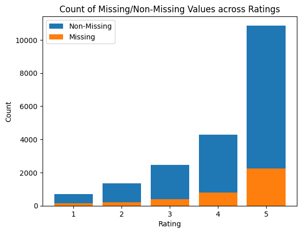

```python
# Group the data by Rating and count the non-missing Title values for each group
grouped_non_missing = review_data['Title'].notnull().groupby(review_data['Rating']).sum()

# Group the data by Rating and count the missing Title values for each group
grouped_missing = review_data['Title'].isnull().groupby(review_data['Rating']).sum()

# Plot the count of non-missing values
plt.bar(grouped_non_missing.index, grouped_non_missing.values, label='Non-Missing')
# Plot the count of missing values
plt.bar(grouped_missing.index, grouped_missing.values, label='Missing')

# Format the plots
plt.xlabel('Rating')
plt.ylabel('Count')
plt.title('Count of Missing/Non-Missing Values across Ratings')
plt.legend()
plt.show()
```

Next, the rows with missing values can be removed and a new count of the data is taken. After removal, the dataset contains just under 20000 rows, which is still a good size.

```python
# Remove rows with missing values
Review_Data = review_data.dropna()
print(Review_Data.isnull().sum().sort_values(ascending=False))
print(f'The dataset has {Review_Data.shape[0]} rows and {Review_Data.shape[1]} columns.\n')  # Checking the shape of the data
```

```
Unnamed: 0                 0
Clothing ID                0
Age                        0
Title                      0
Review Text                0
Rating                     0
Recommended IND            0
Positive Feedback Count    0
Division Name              0
Department Name            0
Class Name                 0
dtype: int64
The dataset has 19662 rows and 11 columns.
```

In order to preprocess the text data, a variety of tools will be used. First, the English language model of spaCy has been loaded. spaCy is a useful library for NLP that provides functions for many essential methods such as tokenisation and lemmatisation. The English language model is a pre-trained model that provides the information for this functions to work.

```python
# Load the spaCy English language model
nlp = spacy.load("en_core_web_sm")
```

Before preprocessing the text data, it is worth looking at an example row so that the changes carried out can be easily seen. The example here is a review for a jumpsuit that contains capital letters, punctuation, as well as many unnecesary words that may need to be removed.

```python
# Print an example row from the Review Text column
text = Review_Data.iloc[1]["Review Text"]
print(text)
```

```
I love, love, love this jumpsuit. it's fun, flirty, and fabulous! every time i wear it, i get nothing but great compliments!
```

The code block below defines a function that performs all of the required preprocessing for a column of text data.

First, the function performs tokenisation and lemmatisation on the text. Tokenisation breaks down the text into a sequence of smaller units called tokens, which will usually be each individual word. Lemmatisation then reduces these tokens into their base form, or lemma. For example, walk, walking, and walks, would all lemmatise to the root form of walk. This helps standardise different forms of worms for further analysis.

Then, the function uses regular expressions to remove non-alphabetic characters other than the symbols "@" "!" and "?". Regular expressions are sequences of characters that can be used for pattern matching in text data. Here, regular expressions are used to substitute out unnecessary text. Removing punctuation can cause issues in instances such as acronyms, clitics, and contractions. However, for this data set acronyms are unlikely to cause much of a problem. Exclamation marks and question marks have been kept in the data as they can potentially contain information that can be used later on for sentiment analysis. For example, "good!!!" is likely to be more intensely positive than simply "good".

Next, regular expressions are also used to remove websites and email addresses. This is achieved by using the "@" symbol that was kept in the previous step, as well as looking for sub strings containing "com" that would be found in web addresses. Other forms of these could exist, but this should do a good job of removing the majority of this unwanted information.

After that, stop words are removed from the text data. Stop words are common words such as "the" or "a" that appear often but do not provide much information or carry much meaning to the sentence overall. The Natural Language Toolkit (NLTK) has a built-in collection of stop words that have been used here. Both the text data and the stop words are converted into lowercase, and then all stop words are removed from the data. Converting the text data to lowercase helps normalise the data, reducing noise. For example, "Good" and "good" likely carry the same meaning, so making the text all lowercase simplifies the vocabulary.

Each of those steps carry certain risks. Making the text lowercase can remove information regarding intensity, such as "GOOD" Vs "good". Removing punctuation can remove information regarding important contractions such as "don't". All of these steps can and should be changed and edited depending on the specific task to get the best performance. However, this list of steps has been chosen as a good starting point to show how the data can be cleaned and pre-processed.

To finish, the text is joined back up into one complete string with spaces between each word.

```python
def clean_text(text):
    # Tokenize the text using spaCy and extract lemmas of non-punctuation tokens that are not '!' or '?'
    words = [token.lemma_ for token in nlp(text) if not (token.is_punct and token.text not in ['!', '?'])]
    # Remove non-alphabetic characters except for '@', '!', and '?'
    words = [re.sub(r"[^A-Za-z@!?]", "", word) for word in words]
    # Remove websites
    words = [re.sub(r"\S+com", "", word) for word in words]
    # Remove email addresses
    words = [re.sub(r"\S+@\S+", "", word) for word in words]
    # Remove empty spaces
    words = [word for word in words if word!='']
    # Get the list of English stopwords
    stopwords = nltk.corpus.stopwords.words("english")
    # Convert stopwords to lowercase
    stopwords_lower = [s.lower() for s in stopwords]
    # Convert the list of words into lowercase and then remove stopwords
    words = [word.lower() for word in words if word.lower() not in stopwords_lower]

    # Join the cleaned words into a single string with spaces in between
    cleaned_text = ' '.join(words)

    # Return the cleaned text
    return cleaned_text
```

To see how that function changes the text, it has been performed on the same example as before. We can see how it is now all lower case and punctuation has been removed except for the "!" characters. Stop words such as "this" have been removed, leaving behind a streamlined review that still captures all of the important information.

```python
# Perform the function on an example row
cleaned_text = clean_text(text)
print(cleaned_text)
```

```
love love love jumpsuit fun flirty fabulous ! every time wear get nothing great compliment !
```

Now that the function has been created and tested, it is applied to all of the rows in both of the text data columns.

```python
# Perform the function on both columns of text data
Review_Data["clean_title"]=Review_Data["Title"].apply(clean_text)
Review_Data["clean_body"]=Review_Data["Review Text"].apply(clean_text)
```

Viewing the head of the data again, we can see a snapshot of the two new columns that have been added and how they are different to the original text columns.

```python
Review_Data.head()
```

|  | Unnamed: 0 | Clothing ID | Age | Title | Review Text | Rating | Recommended IND | Positive Feedback Count | Division Name | Department Name | Class Name | clean_title | clean_body |
| --- | --- | --- | --- | --- | --- | --- | --- | --- | --- | --- | --- | --- | --- |
| 2 | 2 | 1077 | 60 | Some major design flaws | I had such high hopes for this dress and reall... | 3 | 0 | 0 | General | Dresses | Dresses | major design flaw | high hope dress really want work initially ord... |
| 3 | 3 | 1049 | 50 | My favorite buy! | I love, love, love this jumpsuit. it's fun, fl... | 5 | 1 | 0 | General Petite | Bottoms | Pants | favorite buy ! | love love love jumpsuit fun flirty fabulous ! ... |
| 4 | 4 | 847 | 47 | Flattering shirt | This shirt is very flattering to all due to th... | 5 | 1 | 6 | General | Tops | Blouses | flattering shirt | shirt flattering due adjustable front tie perf... |
| 5 | 5 | 1080 | 49 | Not for the very petite | I love tracy reese dresses, but this one is no... | 2 | 0 | 4 | General | Dresses | Dresses | petite | love tracy reese dress one petite foot tall us... |
| 6 | 6 | 858 | 39 | Cagrcoal shimmer fun | I aded this in my basket at hte last mintue to... | 5 | 1 | 1 | General Petite | Tops | Knits | cagrcoal shimmer fun | ade basket hte last mintue see would look like... |

Now that the text data has been pre-processed, wordclouds have been used to get an initial overview of the data. This calculates the most frequently used words in the data and presents them in a cloud with the size relative to the word frequency. This shows that some of the most frequent words in the review titles are very positive such as "love", "cute" and "great".

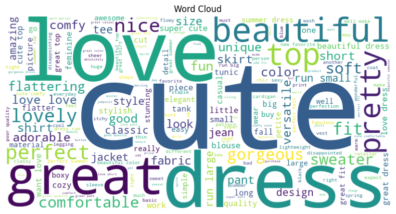

```python
# Produce a word cloud of the most frequently occuring words in the review titles
text_corpus = ' '.join(Review_Data['clean_title'])
wordcloud = WordCloud(width=800, height=400, background_color='white').generate(text_corpus)
plt.figure(figsize=(10, 5))
plt.imshow(wordcloud, interpolation='bilinear')
plt.axis('off')
plt.title('Word Cloud')
plt.show()
```

A wordcloud has also been created for the body of the review. This shows some similar words, but with more contextual words being common such as "look", "think" and "fabric".

Drawing conclusions from these wordclouds is difficult as they contain the data for all of the different item categories and all different review scores. They provide a good overview, but more detail is needed for solid conclusions, which leads on to the next section: Sentiment Analysis.

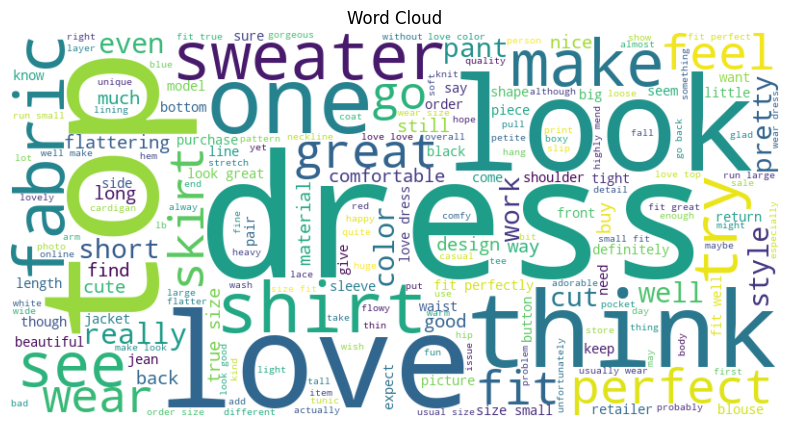

```python
# Produce a word cloud of the most frequently occuring words in the review titles
text_corpus = ' '.join(Review_Data['clean_body'])
wordcloud = WordCloud(width=800, height=400, background_color='white').generate(text_corpus)
plt.figure(figsize=(10, 5))
plt.imshow(wordcloud, interpolation='bilinear')
plt.axis('off')
plt.title('Word Cloud')
plt.show()
```

# Sentiment Analysis

Sentiment analysis refers to the extraction of information from text regarding sentiment. Sentiment could mean text classified as positive, negative, or neutral. It could also mean specific emotions such as happy or sad. This is a useful way of getting information on the thoughts and feelings hidden within text data. In this instance, sentiment analysis can allow to gain an understanding of how the reviewer felt and why they might have felt that way. This way negative sentiment can be addressed, and positive sentiment can be reinforced.

To begin with, labelling the data manually gives a frame of reference that can later be used to assess model performance in classification problems. To do this, each review will be given a label of positive, negative, or neutral. In order to see which label each review should get, the ratings data will be used as well as the recommended IND which shows whether or not the customer recommends the product. Plotting this shows that almost everybody who rated the product a 4/5 or a 5/5 did recommend the product, whilst almost everybody who rated a 1/5 or a 2/5 did not recommend the product. Meanwhile, people who rated the product a 3/5 were fairly split on whether or not they would recommend the product.

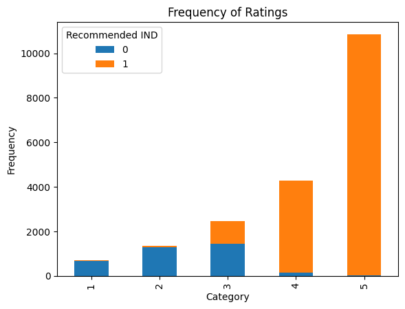

```python
# Calculate the frequency of the 'Rating' column for each value of 'Recommended IND'
category_counts = Review_Data.groupby(['Rating', 'Recommended IND']).size().unstack()

# Plot the frequency, split by 'Recommendd IND'
category_counts.plot(kind='bar', stacked=True)

# Format plot
plt.xlabel('Category')
plt.ylabel('Frequency')
plt.title('Frequency of Ratings')

# Display the plot
plt.show()
```

Based on the above graph, the decision was made to label all reviews with ratings of 4/5 or 5/5 as positive. Meanwhile all reviews with ratings of 1/5 or 2/5 will be labelled as negative, and all reviews with ratings of 3/5 will be labelled as neutral. The below code defines and applies a function that adds this label to a new column in the dataframe. This label is stored as an ordinal variable, with negative being 0, neutral being 1, and positive being 2.

```python
# A function that computes the rating label based on the rating score
def Rating_Value(value):
    if value >= 0 and value <= 2:
        return 0
    elif value == 3:
        return 1
    elif value >= 4 and value <= 5:
        return 2
    else:
        return None

# Apply the function to create column2
Review_Data['Rating_Value'] = Review_Data['Rating'].apply(Rating_Value)
```

The first method of sentiment analysis being conducted is using the Valence Aware Dictionary and sEntiment Reasoner (VADER). VADER is a rule based method of sentiment analysis that has a pre-built lexicon that analyses the sentiment of a text by assigning a polarity score that will be either positive, neutral, or negative. The below uses VADER on the body of the reviews.

```python
# Create the VADER sentiment analyzer
analyzer = SentimentIntensityAnalyzer()

# Define a function to apply VADER sentiment analysis to each row in the DataFrame
def analyze_sentiment_body(row):
    text = row['clean_body']  # Assuming 'preprocessed_text' is the column name
    scores = analyzer.polarity_scores(text)
    # Extract the compound score, which represents the overall sentiment
    sentiment_score = scores['compound']
    return sentiment_score

# Apply the sentiment analysis function to each row in the DataFrame
Review_Data['sentiment_score'] = Review_Data.apply(analyze_sentiment_body, axis=1)
```

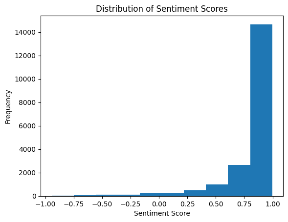

```python
# Plot a histogram of sentiment scores
plt.hist(Review_Data['sentiment_score'], bins=10)
plt.xlabel('Sentiment Score')
plt.ylabel('Frequency')
plt.title('Distribution of Sentiment Scores')
plt.show()
```

Next, the same steps were taken but this time looking at the titles of each review.

```python
# Instantiate the VADER sentiment analyzer
analyzer = SentimentIntensityAnalyzer()

# Define a function to apply VADER sentiment analysis to each row in the DataFrame
def analyze_sentiment_title(row):
    text = row['clean_title']  # Assuming 'preprocessed_text' is the column name
    scores = analyzer.polarity_scores(text)
    # Extract the compound score, which represents the overall sentiment
    sentiment_score = scores['compound']
    return sentiment_score

# Apply the sentiment analysis function to each row in the DataFrame
Review_Data['sentiment_score2'] = Review_Data.apply(analyze_sentiment_title, axis=1)
```

Interestingly, the scores for the review titles show a different distribution of sentiment scores. There are far more neutral scores than before, and a slight increase in negative scores, although still very few negative scores overall. The positive scores also exist within a wider range of values, and slightly lower than in the review text. This could be because titles are likely to be simpler, shorter, and contain different words to the bodies of each review. Titles may contain less noise and less complications such as contractions that could lead to the positive bias seen before.

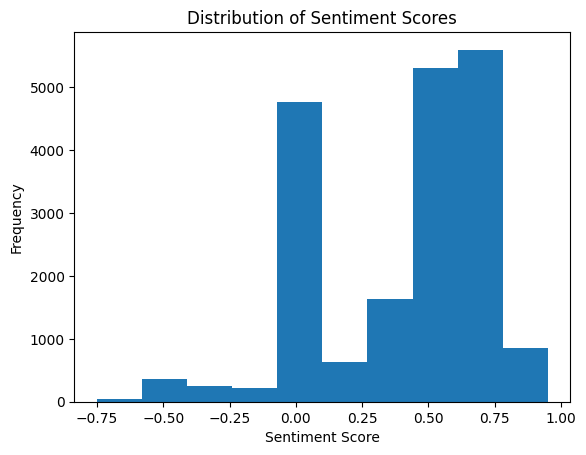

```python
# Plot a histogram of sentiment scores
plt.hist(Review_Data['sentiment_score2'], bins=10)
plt.xlabel('Sentiment Score')
plt.ylabel('Frequency')
plt.title('Distribution of Sentiment Scores')
plt.show()
```

To gain further insights into the thoughts and feelings of the reviewers, wordclouds can be used that separate the positive from the negative using the VADER sentiment scores. The below code creates two wordclouds for the review bodies.

The positive wordcloud shows the most common positive words used. Many of these are generic words such as "dress" and "shirt". However, some such as "fit", "color", "fabric", and "comfortable" provide clear information as to what reviewers may have liked most about the product.

The negative wordcloud shows the most common negative words used. These include the same generic words such as "dress" and "look". However, there is a common theme with words such as "size" and "fit", as well as "make", quality", and "fabric" which suggests that the sizing of certain products as well as the materials and quality may be common customer concerns.

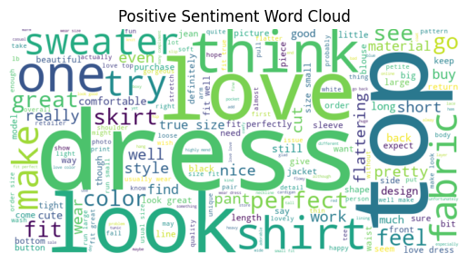

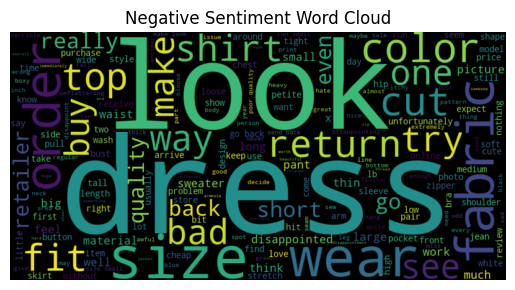

```python
# Extract the positive and negative text for the wordclouds
positive_texts = Review_Data[Review_Data['sentiment_score'] > 0]['clean_body']
negative_texts = Review_Data[Review_Data['sentiment_score'] < 0]['clean_body']

# Create wordclouds
positive_wordcloud = WordCloud(width=800, height=400, background_color='white').generate(' '.join(positive_texts))
negative_wordcloud = WordCloud(width=800, height=400).generate(' '.join(negative_texts))

# Plot positive sentiment word cloud
plt.imshow(positive_wordcloud, interpolation='bilinear')
plt.axis('off')
plt.title('Positive Sentiment Word Cloud')
plt.show()

# Plot negative sentiment word cloud
plt.imshow(negative_wordcloud, interpolation='bilinear')
plt.axis('off')
plt.title('Negative Sentiment Word Cloud')
plt.show()
```

The same method was then used to create wordclouds for the review titles.

The positive wordcloud shows that words such as "cute", "beautiful", and "pretty" were the most common positive words. Meanwhile the negative wordcloud shows that words such as "disappointed", "quality", "itchy", and "poor" were the most common.

Overall, it seems as though quality of certain products could be a cause for concern, with online customers being disappointed that orders either did not fit or did not meet expectations. Customers responded most positively to products that were pretty and cute, with good colours and materials. These insights could inform design and marketing teams for these products to make changes that will improve reviews in the future.

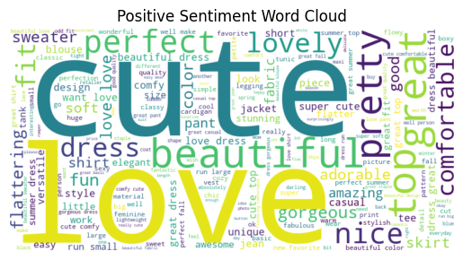

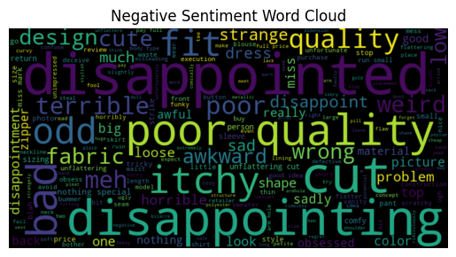

```python
positive_texts = Review_Data[Review_Data['sentiment_score2'] > 0]['clean_title']
negative_texts = Review_Data[Review_Data['sentiment_score2'] < 0]['clean_title']

positive_wordcloud = WordCloud(width=800, height=400, background_color='white').generate(' '.join(positive_texts))
negative_wordcloud = WordCloud(width=800, height=400).generate(' '.join(negative_texts))

# Plot positive sentiment word cloud
plt.imshow(positive_wordcloud, interpolation='bilinear')
plt.axis('off')
plt.title('Positive Sentiment Word Cloud')
plt.show()

# Plot negative sentiment word cloud
plt.imshow(negative_wordcloud, interpolation='bilinear')
plt.axis('off')
plt.title('Negative Sentiment Word Cloud')
plt.show()
```

The next method of sentiment analysis used was the NRC Word-Emotion Lexicon (NRCLex). NRCLex is a lexicon designed for sentiment analysis that measures things on an emotional level. Each word will have associations with the emotions "anger", "anticipation", "disgust", "fear", "joy", "sadness", "surprise", and "trust". This allows for emotion detection in text which can be further analysed.

The code below defines a function that performs sentiment analysis on the body of the reviews using NRCLex.

```python
# Perform sentiment analysis using NCRLex
def analyse_sentiment(row):
    text = row['clean_body']
    sentiment = NRCLex(text)
    sentiment_scores = sentiment.affect_frequencies # Calculate affect frequencies
    sentiment_score = sentiment.raw_emotion_scores # Calculate emotion scores

    return sentiment_scores, sentiment_score
```

The function is then applied to the review bodies and two new columns are formed. The two scores represent the affect frequencies and raw emotion scores of the sentiment analysis. The affect frequencies show the relative frequency of each emotion, whilst the raw emotion score represents the strength or intensity of the emotions. Both of these scores will be plotted.

```python
# Apply sentiment analysis to the preprocessed text column
# Create empty lists to store sentiment scores
sentiment_scores = []
sentiment_score = []
# Iterate over each row with the function
for _, row in Review_Data.iterrows():
    scores, score = analyse_sentiment(row)
     # Append the 'scores' to the lists
    sentiment_scores.append(scores)
    sentiment_score.append(score)

# Assign the scores as new columns in the dataframe
Review_Data['NCRLex_scores'] = sentiment_scores
Review_Data['NCRLex_score'] = sentiment_score
```

The code below shows the same example review for a jumpsuit that has been used before. This shows the sentiment scores of this review. The NCRLex_score shows the raw emotional scores, with joy being the highest at 5. The NCRLex_scores shows the affect frequency, the relative frequency of all the emotions, showing how many of the emotions such as fear and anger are not present in the review at all. This provides an example of how the NCRLex sentiment analysis works before the results are plotted.

```python
# Specify the index
index = 3

# Get the value from the specified index and column
column_name1 = 'clean_body'
value1 = Review_Data.loc[index, column_name1]
print(value1)


# Get the value from the specified index and column
column_name2 = 'NCRLex_score'
value2 = Review_Data.loc[index, column_name2]
print(value2)

# Get the value from the specified index and columnc
column_name3 = 'NCRLex_scores'
value3 = Review_Data.loc[index, column_name3]
print(value3)
```

```
love love love jumpsuit fun flirty fabulous ! every time wear get nothing great compliment !
{'joy': 5, 'positive': 5, 'anticipation': 3, 'negative': 1, 'trust': 2, 'surprise': 1}
{'fear': 0.0, 'anger': 0.0, 'anticip': 0.0, 'trust': 0.11764705882352941, 'surprise': 0.058823529411764705, 'positive': 0.29411764705882354, 'negative': 0.058823529411764705, 'sadness': 0.0, 'disgust': 0.0, 'joy': 0.29411764705882354, 'anticipation': 0.17647058823529413}
```

The plot below shows the relative frequency of each emotion in the review bodies. The positive emotions, "joy", "anticipation", and "trust" all appeared the most frequently. For negative emotions "sadness" was the most common. Overall, positive emotions have a much higher relative frequency. This is to be expected as there are a lot more positive reviews than negative reviews. However, this allows us to dive deeper into exactly which positive emotions are being generated. For example, a customer feeling anticipation could linked to marketing and how hype for the product was generated, whereas a customer feeling joy could be more directly linked to the quality and appeal of the product itself. This is speculative, but the individual words that make up these emotions could then be analysed to see exactly what is generating specific emotional responses.

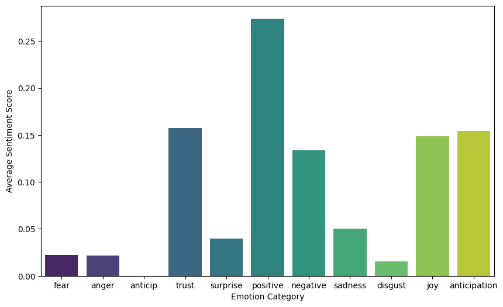

```python
# Calculate the average sentiment scores for each emotion category
average_scores = pd.DataFrame(Review_Data['NCRLex_scores'].tolist()).mean()

# Plot the bar chart
plt.figure(figsize=(10, 6))
sns.barplot(x=average_scores.index, y=average_scores.values, palette='viridis')
plt.xlabel('Emotion Category')
plt.ylabel('Average Sentiment Score')
plt.show()
```

The next plot shows the average intensity of each emotion across the review bodies. This shows a more even distribution. Overall, positive emotions had a higher intensity than the negative emotions, but the difference of intensity was smaller than the difference in frequency.

These plots could be used to monitor change in emotional affects over time. For example, if changes were made to address the sizing of a particular product, then emotional sentiment of reviews could be compared from before and after the change was made to see if there is any change in frequency or intensity of particular emotions.

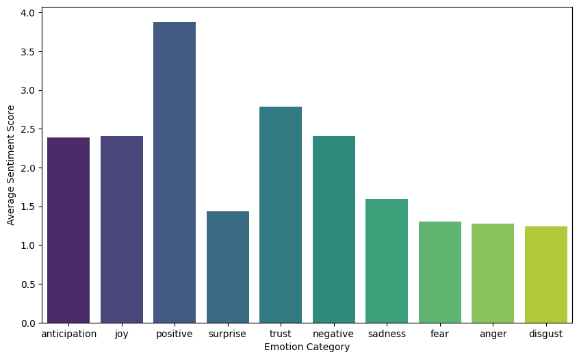

```python
# Calculate the average sentiment scores for each emotion category
average_scores = pd.DataFrame(Review_Data['NCRLex_score'].tolist()).mean()

# Plot the bar chart
plt.figure(figsize=(10, 6))
sns.barplot(x=average_scores.index, y=average_scores.values, palette='viridis')
plt.xlabel('Emotion Category')
plt.ylabel('Average Sentiment Score')
plt.show()
```

So far the analysis has been conducted on the corpus as a whole. However, sentiment analysis can be used to look at each item category independently. The below code filteres the dataset to only the rows with a class name of "Dresses" and then performs the VADER analysis and plots more wordclouds. This means that each product type can be analysed to see what positive and negative words are most associated with them. Some words appear in both wordclouds, however it is likely the words that appear much larger in one wordcloud that are of particular interest. For example, "size" is one of the most relevant words in the negative wordcloud, whilst not being very relevant in the positive wordcloud. This could indicate that the size of the dresses is a common cause of concern for customers. This shows how sentiment analysis can be used to try and identify what customers may like or dislike about individual products, which could be very useful in informing future decisions made by the retailers or designers etc.

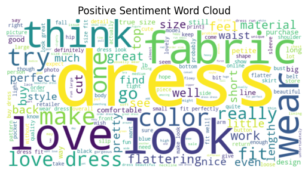

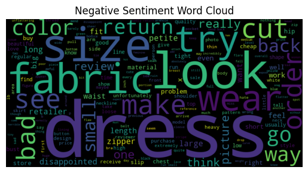

```python
def filter_dataset(original_dataset, column_name, filter_value):
    filtered_dataset = original_dataset.copy()
    filtered_dataset = filtered_dataset[filtered_dataset[column_name] == filter_value]
    return filtered_dataset

# Example usage
# Assuming you have a pandas DataFrame named 'original_dataset' with multiple columns including 'column_to_filter'

# Filter the dataset based on a particular value in the 'column_to_filter'
filtered_value = 'Dresses'
filtered_dataset = filter_dataset(Review_Data, 'Class Name', filtered_value)

# Create the VADER sentiment analyzer
analyzer = SentimentIntensityAnalyzer()

# Apply the sentiment analysis function to each row in the DataFrame
filtered_dataset['sentiment_score_filtered'] = filtered_dataset.apply(analyze_sentiment_body, axis=1)

# Extract the positive and negative text for the wordclouds
positive_texts = filtered_dataset[filtered_dataset['sentiment_score_filtered'] > 0]['clean_body']
negative_texts = filtered_dataset[filtered_dataset['sentiment_score_filtered'] < 0]['clean_body']

# Create wordclouds
positive_wordcloud = WordCloud(width=800, height=400, background_color='white').generate(' '.join(positive_texts))
negative_wordcloud = WordCloud(width=800, height=400).generate(' '.join(negative_texts))

# Plot positive sentiment word cloud
plt.imshow(positive_wordcloud, interpolation='bilinear')
plt.axis('off')
plt.title('Positive Sentiment Word Cloud')
plt.show()

# Plot negative sentiment word cloud
plt.imshow(negative_wordcloud, interpolation='bilinear')
plt.axis('off')
plt.title('Negative Sentiment Word Cloud')
plt.show()
```

The final method of sentiment analysis used was a Multinomial Naive Bayes model (MNB) for text classification. MNB is a machine learning algorithm based on Bayes's theorem that can be used for many classification tasks.

In order to perform MNB, the text data must be vectorised as most machine learning algorithms require numerical inputs. To achieve this, Term Frequency-Inverse Document Frequency (TF-IDF) has been used. TF-IDF multiplies the frequency of a term within a document by the inverse of the frequency of documents containing that term. This transforms the text data into a vector that can be used in MNB classification.

In this instance, the review body text will be split into a training and test set for the machine learning model. The review body will be used as opposed to the title as the bodies should be longer and contain more information. The model will predict if reviews in the test set are positive, neutral, or negative, and accuracy will be calculated using the rating values column previously created. A range of performance metrics are then calculated, and a confusion matrix has been plotted.

Immediately from the results, a problem can be seen. The model predicts almost every single review as being positive. This is likely due to the data being so imbalanced. The vast majority of the reviews are positive, so a model predicting the positive class every time would have deceptively high accuracy. This basic model clearly does not perform well and will need to be looked into further.

```
Accuracy: 0.782608695652174
Precision: 0.7235009869912745
Recall: 0.782608695652174
F1 Score: 0.6875235102347889

Classification Report:
              precision    recall  f1-score   support

           0       1.00      0.00      0.00       437
           1       0.00      0.00      0.00       419
           2       0.78      1.00      0.88      3077

    accuracy                           0.78      3933
   macro avg       0.59      0.33      0.29      3933
weighted avg       0.72      0.78      0.69      3933
```

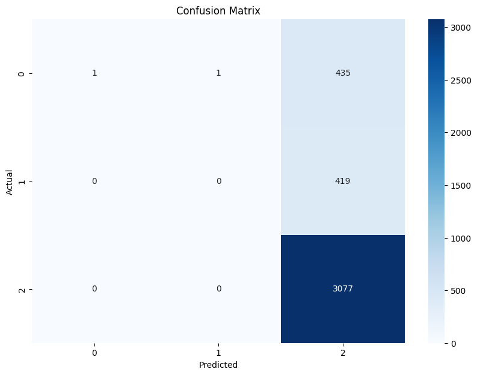

```python
# Prepare labeled  data
X = Review_Data["clean_body"]  # Preprocessed review texts
y = Review_Data["Rating_Value"]  # Corresponding sentiment labels (multi-class)

# Feature extraction using TF-IDF
vectorizer = TfidfVectorizer()  # Use TF-IDF vectorizer
X = vectorizer.fit_transform(X)

# Split into test and train sets
X_train, X_val, y_train, y_val = train_test_split(X, y, test_size=0.2, random_state=42)

# Train the Multinomial Naive Bayes classifier
classifier = MultinomialNB()
classifier.fit(X_train, y_train)

# Evaluation
y_pred = classifier.predict(X_val)

# Calculate performance metrics
accuracy = accuracy_score(y_val, y_pred)
precision = precision_score(y_val, y_pred, average='weighted')
recall = recall_score(y_val, y_pred, average='weighted')
f1 = f1_score(y_val, y_pred, average='weighted')

print("Accuracy:", accuracy)
print("Precision:", precision)
print("Recall:", recall)
print("F1 Score:", f1)

# Print classification report
print("\nClassification Report:")
print(classification_report(y_val, y_pred))

# Confusion matrix
confusion_matrix = pd.crosstab(y_val, y_pred, rownames=['Actual'], colnames=['Predicted'])
plt.figure(figsize=(10, 7))
sns.heatmap(confusion_matrix, annot=True, fmt='d', cmap='Blues')
plt.title('Confusion Matrix')
plt.show()
```

To deal with class imbalance, oversampling has been used to see if that improves model performance. The results show that this has decreased the accuracy and recall slightly, but the precision and F1 score have increased a fair amount. This model still does not perform well, but it shows how model tuning and data preprocessing can drastically impact performance. In the extension section of this report, a better performing text classification model will be constructed.

```
Accuracy: 0.7414187643020596
Precision: 0.8324267328679906
Recall: 0.7414187643020596
F1 Score: 0.7746381815464156

Classification Report:
              precision    recall  f1-score   support

           0       0.48      0.51      0.49       437
           1       0.27      0.58      0.37       419
           2       0.96      0.80      0.87      3077

    accuracy                           0.74      3933
   macro avg       0.57      0.63      0.58      3933
weighted avg       0.83      0.74      0.77      3933
```

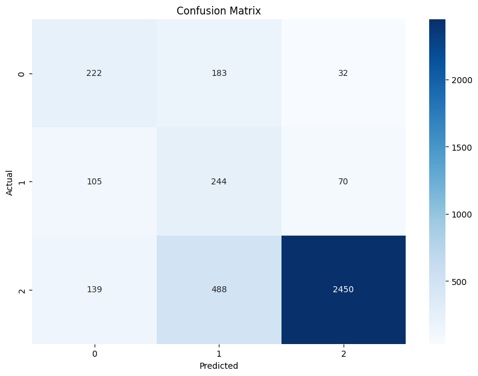

```python
# Prepare labeled  data
X = Review_Data["clean_body"]  # Preprocessed review texts
y = Review_Data["Rating_Value"]  # Corresponding sentiment labels (multi-class)

# Feature extraction using TF-IDF
vectorizer = TfidfVectorizer()  # Use TF-IDF vectorizer
X = vectorizer.fit_transform(X)

# Split data into test and train sets
X_train, X_val, y_train, y_val = train_test_split(X, y, test_size=0.2, random_state=42)

# Apply random oversampling
oversampler = RandomOverSampler(random_state=42)
X_train_resampled, y_train_resampled = oversampler.fit_resample(X_train, y_train)

# Train the Multinomial Naive Bayes classifier with oversampled data
classifier = MultinomialNB()
classifier.fit(X_train_resampled, y_train_resampled)

# Evaluation
y_pred = classifier.predict(X_val)

# Calculate performance metrics
accuracy = accuracy_score(y_val, y_pred)
precision = precision_score(y_val, y_pred, average='weighted')
recall = recall_score(y_val, y_pred, average='weighted')
f1 = f1_score(y_val, y_pred, average='weighted')

print("Accuracy:", accuracy)
print("Precision:", precision)
print("Recall:", recall)
print("F1 Score:", f1)

# Print classification report
print("\nClassification Report:")
print(classification_report(y_val, y_pred))

# Confusion matrix
confusion_matrix = pd.crosstab(y_val, y_pred, rownames=['Actual'], colnames=['Predicted'])
plt.figure(figsize=(10, 7))
sns.heatmap(confusion_matrix, annot=True, fmt='d', cmap='Blues')
plt.title('Confusion Matrix')
plt.show()
```

# Topic Modelling

Topic modelling involves the extraction of topic information from text data. It analyses the distribution of words across all the different reviews in the dataset to see if underlying themes and topics can be identified. This can provide insights into what the key topics are that are within the reviews.

The first method of topic modelling used is Hierarchical Dirichlet Process (HDP) which is a model that can be used to identify the ideal number of topics within the corpus. HDP uses a hierarchical structure with broad topics at the top, branching down into smaller subtopics. HDP does not have a fixed number of topics, and flexibly infers the ideal number of topics by looking at the distribution of topic probabilities. The code below performs HDP on the review bodies.

```python
from gensim.models import HdpModel
from gensim.corpora import Dictionary

texts = []  # List to store preprocessed texts

for review in Review_Data['clean_body']:
    tokens = word_tokenize(review)  # Tokenize
    texts.append(tokens)

# Create dictionary and document-term matrix
dictionary = corpora.Dictionary(texts)  # Create a dictionary of unique tokens
corpus = [dictionary.doc2bow(text) for text in texts]  # Convert the text to bag-of-words (BoW) format

# Train the HDP model
hdp_model = HdpModel(corpus, id2word=dictionary)

# Print the topics
#topics = hdp_model.show_topics()
#for topic in topics:
    #print(topic)
```

Latent Dirichlet Allocation (LDA) is the model that HDP is based on. LDA models the generation of documents under the assumption that every document is built from a variety of topics and that every topic is composed of a variety of words. The code below performs LDA with 20 topics as that was considered the ideal amount by the HDP model.

The results show the 20 topics and assigns each document with its most probable topic. These results will now be plotted for further analysis.

```python
texts = []  # List to store preprocessed texts

for review in Review_Data['clean_body']:
    tokens = word_tokenize(review)  # Tokenize
    texts.append(tokens)

# Create dictionary and document-term matrix
dictionary = corpora.Dictionary(texts)  # Create a dictionary of unique tokens
corpus = [dictionary.doc2bow(text) for text in texts]  # Convert the text to bag-of-words (BoW) format

# Perform LDA
num_topics = 20  # Number of topics to extract
lda_model = models.LdaModel(corpus, num_topics=num_topics, id2word=dictionary, passes=10)

# Print the topics and their top words
#topics = lda_model.print_topics(num_words=10)
#for topic in topics:
    #print(topic)

# Assign the most probable topic to each document
topic_assignments = [max(lda_model[doc], key=lambda x: x[1])[0] for doc in corpus]

# Add the topic assignment to the DataFrame
Review_Data['topic_assignment'] = topic_assignments
```

To visualise the results of the LDA topic modelling, the pyLDAvis library has been used. This creates an interactive visualisation with a scatterplot showing the relationships between topics, with a closer distance meaning the topics are more similar to each other. The size of the circles shows how prevalent each topic is, and hovering over each circle you can see the percentage of tokens that are in that topic. You can also then view a bar chart of the most relevant terms for each topic and see how they compare to the frequency in the corpus as a whole. This provides a great level of insight into each topic, which topics are the most prevalent, and what terms each topic is composed of. For example, you can clearly see small topics, 10, 16, and 14 are far away from the other topics, indicating they are in their own separate, more similar cluster. Looking at the bar charts, topic 10 contains all of the use of the word "blouse" and topic 14 contains all of the use of the word "sweater. This means those topics can probably be labelled as terms related to blouses and sweaters, and that those topics are more similar to each other than they are to other topics.

The most prevalent topic is topic 9 with contains ~12% of tokens. The words contained in this topic include "size", "small", "large", "fit", "medium", "big", "little" and many other terms to do with size and fitting. Therefore this topic has likely accurately captured size related themes in the text. This also contains a high relevance to the word "order", meaning this topic is likely related to clothes ordered online and how they fit. The most closely related topic to this is topic 18, with the most common words in this topic being "petite", "short", "length", and "long". It is clear these topics are similar due to being closely related to size and fitting. The difference seems to be that topic 18 is more focussed on small sizings, containing all of the frequency of the word "petite" and most of the frequency of the word "short". These two topics provide a good example of how the LDA topic modelling has worked, and it seems to have performed reasonably well, accurately identifying themes in the text regarding the size and fitting of products. A lot of useful information can be drawn from this. For example, topic 15 seems to refer to skirts, topic 3 contains most of the information regarding colour, and topic 1 seems to contain information regarding the customer journey and experience with words such as "store", "try", "see", "buy", "online" and "retailer".

```python
pyLDAvis.enable_notebook()
lda_vis_data = gensimvis.prepare(lda_model, corpus, dictionary, sort_topics=False)
pyLDAvis.display(lda_vis_data)
```

[interactive chart not shown]

The next method that I implemented was t-SNE to visualise the topics in a 2-dimensional space. t-distributed stochastic neighbour embedding, is a nonlinear dimensionality reduction technique that can be used to visualize high-dimensional data in two or three dimensions. It can be useful for visualizing clusters, patterns, and trends, and in this case can be used to visualise how the different topics relate to each other, and how well each topic clusters.

The code below implements t-sne for the 20 topics of the LDA model. The plot shows how these topics cluster and group with each other. The topics actually cluster fairly well, with colours operating within different spaces. There is some overlap, and some of the topics appear to cluster better than others, but overall they group well.

This can also provide insights into which topics are more similar to one another, and which themes may be the most related. Overall, visualising the topics in this way can help us understand the underlying structures running throughout the corpus.

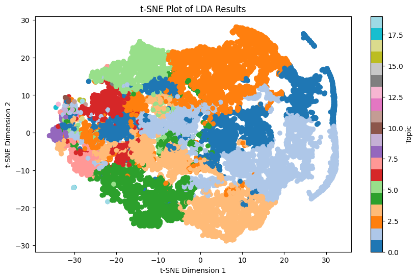

```python
import numpy as np
from sklearn.manifold import TSNE
import matplotlib.pyplot as plt

# Fit LDA model and obtain topic distribution for each document
lda_model2 = lda_model  # Replace with your LDA model
topic_distributions = [lda_model2.get_document_topics(doc) for doc in corpus]  # Replace with your corpus

# Find the maximum number of topics across all documents
max_topics = max(len(topics) for topics in topic_distributions)

# Pad shorter topic distributions with zeros
topic_probs = []
for topics in topic_distributions:
    probs = [prob for _, prob in topics]
    probs.extend([0] * (max_topics - len(probs)))
    topic_probs.append(probs)

# Convert topic_probs to a NumPy array
topic_probs = np.array(topic_probs)

# Perform t-SNE on the topic distribution vectors
tsne = TSNE(n_components=2, random_state=42, perplexity=100, learning_rate=30)
topic_tsne = tsne.fit_transform(topic_probs)

#Get the topic indices for each data point
topic_indices = np.argmax(topic_probs, axis=1)

# Plot the t-SNE results with different colors for each topic
plt.figure(figsize=(10, 6))
plt.scatter(topic_tsne[:, 0], topic_tsne[:, 1], c=topic_indices, cmap='tab20')
plt.xlabel('t-SNE Dimension 1')
plt.ylabel('t-SNE Dimension 2')
plt.title('t-SNE Plot of LDA Results')
plt.colorbar(label='Topic')
plt.show()
```

To finish visualising the topic modelling, a network mapping has been used. A network mapping represents the relationship between topics and the most important words in them. The nodes represent each topic or word, and the edges represents the relationships between them. The code below creates a network mapping with a threshold set so that only the most important connections are shown.

The network mapping shows that certain topics such as 5 have no strong connections to other relevant topics, whilst other topics such as topic 4 are very closely linked to a variety of other topics and words.

This provides further information about how the topics relate to each other and the overall topic distribution in the corpus.

It is worth noting that the topic numbers in this networking mapping will be 1 less than in the pyLDAvis display as here the index starts at 0 rather than 1. Comparing the two visualisations can provide a great deal of insight into the underlying themes in the data. For example, 4 and 8 in the network mapping (5 and 9 in the pyLDAvis display) are shown to be connected by the word "size". This connection is not immediately clear in the pyLDAvis display as the topics overall aren't that similar, but when you hover over either topic, it then confirms they do both contain a high frequency of the word "size". This shows how a combination of methods is best when performing topic modelling.

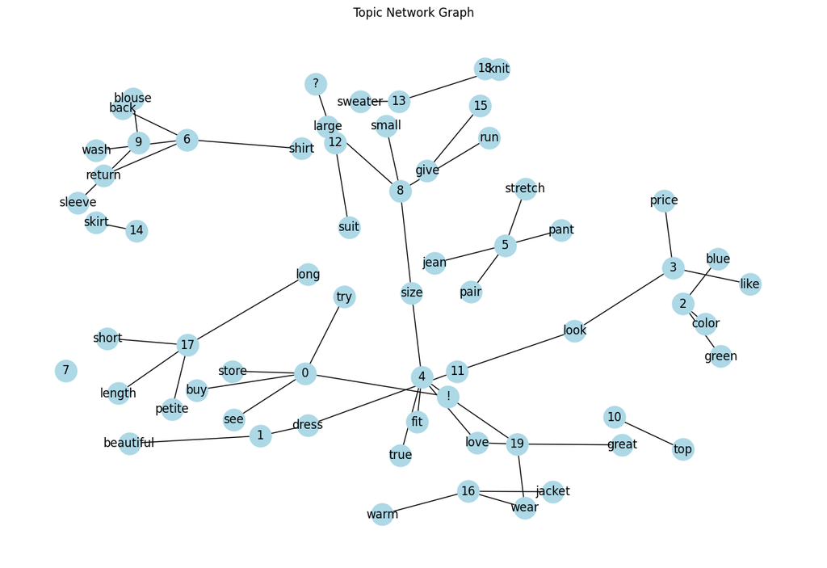

```python
import networkx as nx
import matplotlib.pyplot as plt

# Assuming you have an LDA model named 'lda_model' with 'num_topics' topics

num_topics = 20

# Set the threshold for edge weights
threshold = 0.03


# Create a network graph
G = nx.Graph()

# Add nodes for each topic
for topic_id in range(num_topics):
    G.add_node(topic_id)
    G.add_node(topic_id, label=f'Topic {topic_id}')

# Iterate through the topics and their word distributions
for topic_id, topic_words in lda_model.show_topics(num_topics=num_topics, formatted=False):
    for word, prob in topic_words:
        if prob >= threshold:
            G.add_node(word, label=word)
            G.add_edge(topic_id, word, weight=prob)


# Create a layout for the graph using force-directed layout
pos = nx.spring_layout(G, seed = 25)

# Draw the network graph
plt.figure(figsize=(15, 10))
nx.draw_networkx(G, pos=pos, node_color='lightblue', node_size=500)
plt.title('Topic Network Graph')
plt.axis('off')
plt.show()
```

Overall, the various visualisations of the LDA topic modelling provides great insights into the underlying structure and trends of the corpus. A large number of topics have been identified and can be labelled by looking at the most relevant words in them. Then those topics can be visualised in 2d space to see which topics are linked and which are the most separate. For example topics related to size and fit have been identified and closely linked to each other, topics regarding customer experience and colour have also been identified. Taking all of the information together provides a more complete picture of the topics and the relationships between them. This section has shown how a range of topic modelling methods can be used to gain insight into the themes of a corpus.

# Further Exploration: Text Classification

Text classification can be used for sentiment analysis, to determine the seniment or emotions of a new piece of text. This can be achieved through a variety of models, often in which the model is trained on labelled data as a supervised learning model.

One of the most state of the art models for NLP is Bidirectional Encoder Representations from Transformers (BERT). BERT is a transformer based model developed by google, that is pre-trained on a very large corpus of text data, and is able to understand a lot more of languages nuances than most models. BERT can be a very powerful tool for text classification and sentiment analysis, however it is very computationally expensive and can take a very long time to run. In the code below, I have implemented BERT on the dataset. However, as it is so computationally expensive, I have not yet been able to run it. It seems like the code works, but from what I've researched it could take many hours, if not days to fully run. Therefore I have commented the code out for now, so you can skip past it. I have instead used an XGBoost model for text classification to see if that performs better than the multinomial naive bayes model did. Maybe by the time of the presentation I'll have been able to run this code too!

```python
"""
import torch
from torch.utils.data import Dataset, DataLoader
from transformers import BertTokenizer, BertForSequenceClassification, AdamW

tokenizer = BertTokenizer.from_pretrained('bert-base-uncased')

# Define the dataset class
class SentimentDataset(Dataset):
    def __init__(self, data, tokenizer, max_length):
        self.data = data
        self.tokenizer = tokenizer
        self.max_length = max_length

    def __len__(self):
        return len(self.data)

    def __getitem__(self, index):
        text = self.data['clean_body'].iloc[index]
        label = self.data['Rating_Value'].iloc[index]

        encoding = self.tokenizer.encode_plus(
            text,
            add_special_tokens=True,
            max_length=self.max_length,
            padding='max_length',
            truncation=True,
            return_tensors='pt'
        )

        return {
            'input_ids': encoding['input_ids'].flatten(),
            'attention_mask': encoding['attention_mask'].flatten(),
            'label': torch.tensor(label, dtype=torch.long)
        }

# Create train and test datasets
train_data = Review_Data.sample(frac=0.8, random_state=42)
test_data = Review_Data.drop(train_data.index)

train_dataset = SentimentDataset(train_data, tokenizer, max_length=128)
test_dataset = SentimentDataset(test_data, tokenizer, max_length=128)

# Create data loaders
batch_size = 16  # Modify batch size if needed

train_loader = DataLoader(train_dataset, batch_size=batch_size, shuffle=True)
test_loader = DataLoader(test_dataset, batch_size=batch_size)

# Initialize the BERT model
model = BertForSequenceClassification.from_pretrained('bert-base-uncased', num_labels=3)
device = torch.device('cuda' if torch.cuda.is_available() else 'cpu')
model.to(device)

# Define the optimizer and loss function
optimizer = AdamW(model.parameters(), lr=2e-5)
loss_fn = torch.nn.CrossEntropyLoss()

# Train the model
model.train()
total_loss = 0

for epoch in range(3):
    for batch in train_loader:
        input_ids = batch['input_ids'].to(device)
        attention_mask = batch['attention_mask'].to(device)
        labels = batch['label'].to(device)

        optimizer.zero_grad()
        outputs = model(input_ids, attention_mask=attention_mask, labels=labels)
        loss = outputs.loss
        total_loss += loss.item()
        loss.backward()
        optimizer.step()

    print(f'Epoch {epoch + 1}: Average Loss: {total_loss / len(train_loader)}')
    total_loss = 0

# Evaluate the model
model.eval()
correct = 0
total = 0

with torch.no_grad():
    for batch in test_loader:
        input_ids = batch['input_ids'].to(device)
        attention_mask = batch['attention_mask'].to(device)
        labels = batch['label'].to(device)

        outputs = model(input_ids, attention_mask=attention_mask)
        predictions = torch.argmax(outputs.logits, dim=1)
        correct += (predictions == labels).sum().item()
        total += labels.size(0)

accuracy = correct / total
print(f'Test Accuracy: {accuracy * 100:.2f}%') """
```

The code below implements an XGBoost model on the review bodies and outputs a range of performance metrics. Overall, even without hyperparameter tuning, the XGBoost model performs better on all metrics apart from precision. Accuracy and recall have both significantly improved, and the F1 score has slightly improved too. This shows that with further tuning, there is the potential for a well performing text classification model to be built.

```python
# Split the data into features (X) and target (y)
X = Review_Data['clean_body']
y = Review_Data['Rating_Value']

# Split the data into training and testing sets
X_train, X_test, y_train, y_test = train_test_split(X, y, test_size=0.2, random_state=42)

# Define the pipeline
pipeline = Pipeline([
    ('tfidf', TfidfVectorizer()),  # Apply TF-IDF vectorization to text data
    ('oversample', SMOTE(sampling_strategy={0: 10000, 1: 10000})),  # Oversample negative and neutral classes
    ('xgb', XGBClassifier())  # XGBoost classifier
])

# Fit the pipeline to the training data
pipeline.fit(X_train, y_train)

# Predict the labels for the test data
y_pred = pipeline.predict(X_test)

# Calculate performance metrics
accuracy = accuracy_score(y_test, y_pred)
precision = precision_score(y_test, y_pred, average='weighted')
recall = recall_score(y_test, y_pred, average='weighted')
f1 = f1_score(y_test, y_pred, average='weighted')

# Print the performance metrics
print("Accuracy:", accuracy)
print("Precision:", precision)
print("Recall:", recall)
print("F1-Score:", f1)
```

```
Accuracy: 0.8197304856343758
Precision: 0.7880095161581375
Recall: 0.8197304856343758
F1-Score: 0.7988503090347471
```

# Conclusion

Overall, text mining and natural language processing methods have been shown to be incredibly useful at gathering insights from text data. Preprocessing can enable text data to be more interpretable by computers for analysis. Sentiment analysis can provide insights into how customers think and feel about particular products and the retailer overall. Topic modelling helps draw a detailed picture of the underlying structure and themes of the corpus as a whole.

For this dataset, these methods have revealed a lot of interesting information. For example, sentiment analysis has shown that the size and fit of many different products may be a common problem. Sentiment analysis has also shown that positive emotions such as joy and anticipation are most commonly felt, and most of the reviews are very positive. Dissapointment in the quality and materials of certain products is also something that could be a common problem. Topic modelling has shown that there are many underlying themes in the reviews such as product size, colour, and customer journey. This can be used to better understand the common things customers are thinking about to identify what should be focused on in the future.

There are a huge number of different ways that this sort of analysis could be expanded. All different item categories could be looked at and analysed with more time. Which words are triggering particular emotions, such as joy or anger, the most often could also be looked into to gain a deeper level of insight into customers emotional responses. Text classification models could be further tuned, and more cutting edge methods could also be looked into.

Text data contains a huge wealth of information, and further analysis could draw out even more depth of knowledge.